# RMarkdown Assignment

Clara Buchholtz

2/5/2020

## Introduce your dissertation or thesis

Broadly speaking I am studying biodiversity loss and extinction events. My project focuses around rare endemic plants in Idaho (specifically Mulford’s milkvetch right now, and probably a suite of others as this project grows), and trying to piece together which cumulative impacts are most responsible for their declines. One type of impact that has a lot of data gaps is recreation. Because of this, part of my work focuses on filling data needs and information gaps regarding the where, when, how much, and why questions of recreation impacts on the landscape.

## Study Area

My study area is centered around the three areas with known Mulford’s milkvetch popultations: The Boise foothills, the Owyhee Front, and the area around Weiser, ID. The most complete existing recreation data that exists between these three areas is in the Boise Foothills, in large part thanks to efforts by the Ridge to Rivers organization. Below is a map of the existing trail networks for this area.

```r
HappyTrails <- readOGR("/Users/Clara/Dropbox/Coursework/Spring_2020/Spatial_Data_in_R/Various_Files/MarkdownAssignment/Urban_and_Foothill_Ridge_to_River_Trails.shp")
```

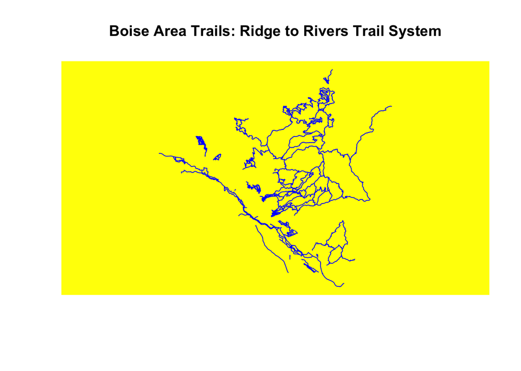

```r
plot(HappyTrails, main = "Boise Area Trails: Ridge to Rivers Trail System",
     sub="",
     col="blue",
     bg="yellow")
```

## Map an attribute of your data

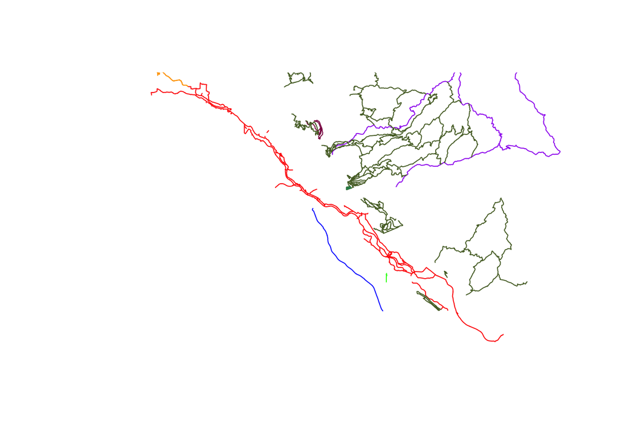

```r
#HappyTrails@data
#checking out this data. The trail system name seems like a fun thing to plot. I'll try to make each trail system a different color.

HappyFRAME<-fortify(HappyTrails) #turn the shapefile into a data frame, so that ggplot can read it. sf could have read it as is.

#This is porbably not  the best way to make this happen, but this shows the different
#kinds of trails that exist in the Ridge to Rivers system
systems <- unique(HappyTrails$SystemName)
color_systems <- c("red", "orange", "blue", "green", "purple", "deeppink4", "darkslateblue", "darkolivegreen", "firebrick", "cornsilk", "seagreen")
plot(HappyTrails[which(HappyTrails$SystemName == systems[1]),], col = color_systems[1])
plot(HappyTrails[which(HappyTrails$SystemName == systems[2]),], col = color_systems[2], add = T)
for(i in 2:length(systems)){
  plot(HappyTrails[which(HappyTrails$SystemName == systems[i]),], col = color_systems[i], add = T)
}
```

## Plot your data a different way

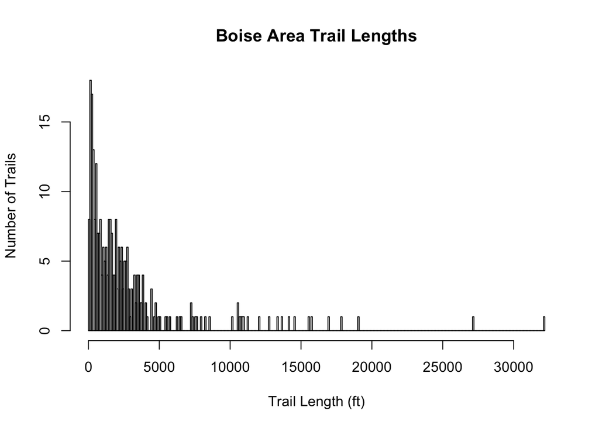

```r
#I'd like to see the distribution of trail lengths. This could be a potentially informative thing to look at, and I wonder if once I eventually add the informal trails in if this would change. My guess is we would see a big spike in very short trails.

hist(HappyTrails$Shape__Len, breaks= 300, xlab="Trail Length (ft)", ylab="Number of Trails", main="Boise Area Trail Lengths")
```

```r
#str(HappyTrails)
```

## What did you learn?

I think it was interesting to think of spatial data outside of a spatial context. Putting trail lengths into a histogram was a very simple operation, but definitley made me think differently about my data. I didn’t realize how such a grand majority of the trails would all be within the same length range. I wonder why that is? And I wonder if that differs between different areas and trail designations. Ultimately trail length may not be the most interesting feature to look at this way, but it was quite accessible with the data I’m currently exploring here. But I can imagine other variables (even trail width, which has some correspondence to maintenence) being especially informative when looked at this way. Overall the idea that one should always be considering whether the thing we need from our data is inherently spatial is a good thing to keep in mind, and something I hadn’t considered before.